# Predicting Toxic Shellfish with Neural Networks

Johnathan Evanilla

12/28/2022

## Packages

```r
library(dplyr)
library(keras)
library(ggplot2)


library(psptools) ## do we need to load this or does sourcing the function file take care of it ##
library(reticulate)
```

## Source some home grown functions

```r
source("02_neural_network_hab_functions.R")
```

Read in csv file with raw data. Each row in table represents a unique shellfish toxicity measurement. The column ‘total_toxicity’ is a sum of the 12 toxins t1-t12. Additionally, we have collected sea surface temperature (sst), cumulative sea surface temperature (sst_cum), and photosynthetic active radiation 8 day rolling average (par_8DR).

```r
raw_data <- readr::read_csv("02_neural_network_hab_data.csv") %>%
  psptools::log_inputs(vars = c("t1", "t2", "t3", "t4", "t5", "t6", "t7", "t8", "t9", "t10", "t11", "t12"))

str(raw_data)
```

```
## tibble [6,273 × 22] (S3: tbl_df/tbl/data.frame)
##  $ id            : chr [1:6273] "PSP10.011_2014-05-19_mytilus" "PSP10.011_2014-05-26_mytilus" "PSP10.011_2014-06-02_mytilus" "PSP10.011_2014-06-03_mytilus" ...
##  $ location_id   : chr [1:6273] "PSP10.011" "PSP10.011" "PSP10.011" "PSP10.011" ...
##  $ date          : Date[1:6273], format: "2014-05-19" "2014-05-26" ...
##  $ gap_days      : num [1:6273] 0 7 7 1 6 7 7 7 7 7 ...
##  $ year          : num [1:6273] 2014 2014 2014 2014 2014 ...
##  $ classification: num [1:6273] 0 0 0 0 0 0 0 0 0 0 ...
##  $ total_toxicity: num [1:6273] 4.196 0.263 7.638 1.585 0.421 ...
##  $ t1            : num [1:6273] 0 0 0 0 0 0 0 0 0 0 ...
##  $ t2            : num [1:6273] 0.716 0 0 0 0 ...
##  $ t3            : num [1:6273] 0 0 0 0 0 0 0 0 0 0 ...
##  $ t4            : num [1:6273] 0 0 0 0 0 0 0 0 0 0 ...
##  $ t5            : num [1:6273] 0 0 0 0 0 0 0 0 0 0 ...
##  $ t6            : num [1:6273] 0 0.101 0.674 0.412 0.153 ...
##  $ t7            : num [1:6273] 0 0 0 0 0 0 0 0 0 0 ...
##  $ t8            : num [1:6273] 0 0 0 0 0 0 0 0 0 0 ...
##  $ t9            : num [1:6273] 0 0 0 0 0 0 0 0 0 0 ...
##  $ t10           : num [1:6273] 0 0 0.692 0 0 ...
##  $ t11           : num [1:6273] 0 0 0 0 0 0 0 0 0 0 ...
##  $ t12           : num [1:6273] 0 0 0 0 0 0 0 0 0 0 ...
##  $ sst           : num [1:6273] 283 284 286 286 287 ...
##  $ sst_cum       : num [1:6273] 38558 40546 42536 42822 44543 ...
##  $ par_8DR       : num [1:6273] 45.1 38.5 50 52.5 49.4 ...
```

Make images from raw data using the function ‘make_image_list,’ which returns a list of lists. Each element of the list contains an ‘image’ pulled from the raw toxin data along with its station, date, etc.

Specify bins for toxicity classification, number of gaps in image, number of gaps ahead forecast is valid for, and size of gap (between samples in image)

Split up training images by year to test on one season

Make train and test objects that have 2d array of all images and their labels

```r
#Generate images from data
image_list <- make_image_list(raw_data,
                              tox_levels =     c(0,10,30,80),
                              forecast_steps = 1,
                              n_steps =        3,
                              minimum_gap =    4,
                              maximum_gap =    10,
                              toxins =         c("t1", "t2", "t3", "t4", "t5", "t6", "t7", "t8", "t9", "t10", "t11", "t12"),
                              environmentals = c("sst_cum"))
```

```r
#Splits image_list by year for grouping into train/test data
years <- sapply(image_list, function(x) {return(x$year)})
image_list <- split(image_list, years)
```

```r
#configuration
YEARS_TRAINING <-   c("2014", "2015", "2016")
YEARS_TESTING <-    "2017"

#Make a training set
train <- pool_images_and_labels(image_list[YEARS_TRAINING], num_classes = 4)

#Make a test set
test <- pool_images_and_labels(image_list[YEARS_TESTING], num_classes = 4)
```

```r
str(train)
```

```
## List of 7
##  $ labels         : num [1:3520, 1:4] 1 1 1 1 1 1 1 1 1 1 ...
##  $ image          : num [1:3520, 1:39] 0 0 0 0 0 0 0 0 0 0 ...
##  $ classifications: num [1:3520] 0 0 0 0 0 0 0 0 0 0 ...
##  $ toxicity       : num [1:3520] 1.475 0 0 0 0.751 ...
##  $ locations      : chr [1:3520] "PSP10.011" "PSP10.07" "PSP11.17" "PSP10.25" ...
##  $ dates          : num [1:3520] 16279 16659 16266 16293 16636 ...
##  $ scaling_factors: NULL
```

```r
dim(train$image)
```

```
## [1] 3520   39
```

Define model architecture

Dense layers - define units and activation function Input shape in first (input) layer

```r
model <- keras_model_sequential() %>%
  layer_dense(units=64,
              activation = "relu",
              input_shape = dim(train$image)[2],
              name = "input_layer") %>%
  layer_dropout(rate = 0.4,
                name = "dropout_1") %>%
  layer_dense(units=32,
              activation = "relu",
              name = "hidden_1") %>%
  layer_dropout(rate=0.3,
                name = "dropout_2") %>%
  layer_dense(units=32,
              activation = "relu",
              name = "hidden_2") %>%
  layer_dropout(rate=0.2,
                name = "dropout_3") %>%
  layer_dense(units = 4,
              activation = "softmax",
              name = "output")

summary(model)
```

```
## Model: "sequential"
## ________________________________________________________________________________
## Layer (type)                        Output Shape                    Param #
## ================================================================================
## input_layer (Dense)                 (None, 64)                      2560
## ________________________________________________________________________________
## dropout_1 (Dropout)                 (None, 64)                      0
## ________________________________________________________________________________
## hidden_1 (Dense)                    (None, 32)                      2080
## ________________________________________________________________________________
## dropout_2 (Dropout)                 (None, 32)                      0
## ________________________________________________________________________________
## hidden_2 (Dense)                    (None, 32)                      1056
## ________________________________________________________________________________
## dropout_3 (Dropout)                 (None, 32)                      0
## ________________________________________________________________________________
## output (Dense)                      (None, 4)                       132
## ================================================================================
## Total params: 5,828
## Trainable params: 5,828
## Non-trainable params: 0
## ________________________________________________________________________________
```

Compile model by selecting an optimizer and loss/metric to track performance

```r
model %>% keras::compile(optimizer =  "adam",
                         loss =       "categorical_crossentropy",
                         metrics =    "categorical_accuracy")
```

Train the model on the training data

Specify how much training data to pass through the network at once (batch_size), how long (epochs), how much training data to withhold for performance assessment between epochs, and whether or not to shuffle the training data before splitting off a validation set.

```r
model %>% keras::fit(x = train$image,
                     y = train$labels,
                     batch_size = 128,
                     epochs = 64,
                     validation_split = 0.2,
                     shuffle = TRUE)
```

Test the model with data it has not seen yet (test set).

```r
metrics <- model %>%
  evaluate(x = test$image,
           y = test$labels)

predictions <- model %>%
  predict(test$image) %>%
  k_argmax() %>%
  as.vector()

predicted_probs <- model %>%
      predict(test$image)
```

Hindcast results can be viewed in table form Each row represents a prediction made for 1 step ahead of the date shown at a sampling site

```r
results <- dplyr::tibble(location = test$locations,
                         date = as.Date(as.numeric(test$dates), origin = as.Date("1970-01-01")),
                         actual_classification = test$classifications,
                         predicted_classification = predictions) %>%
      dplyr::mutate(prob_0 = predicted_probs[,1]*100,
                    prob_1 = predicted_probs[,2]*100,
                    prob_2 = predicted_probs[,3]*100,
                    prob_3 = predicted_probs[,4]*100)

results
```

```
## # A tibble: 981 × 8
##    location  date       actual_classifica…¹ predi…² prob_0 prob_1 prob_2  prob_3
##    <chr>     <date>                   <dbl>   <dbl>  <dbl>  <dbl>  <dbl>   <dbl>
##  1 PSP23.01  2017-06-13                   1       0  83.9   15.4   0.725 3.23e-2
##  2 PSP12.28  2017-05-01                   2       2  13.4   27.1  35.0   2.44e+1
##  3 PSP27.16  2017-07-30                   0       0  62.5   30.3   6.40  7.84e-1
##  4 PSP12.13  2017-05-21                   3       2   5.17  23.9  44.7   2.62e+1
##  5 PSP14.35  2017-07-16                   1       0  84.0   15.3   0.628 2.44e-2
##  6 PSP22.3   2017-07-03                   0       1  25.1   33.5  27.8   1.36e+1
##  7 PSP11.17  2017-05-14                   0       0  90.2    9.49  0.266 1.17e-2
##  8 PSP17.20  2017-05-31                   0       0  92.9    6.94  0.117 4.10e-3
##  9 PSP12.01  2017-07-17                   0       0  82.9   16.1   0.957 5.92e-2
## 10 PSP12.003 2017-07-17                   0       0  86.0   13.5   0.484 1.66e-2
## # … with 971 more rows, and abbreviated variable names ¹actual_classification,
## #   ²predicted_classification
```

Make a confusion matrix to visualize model performance

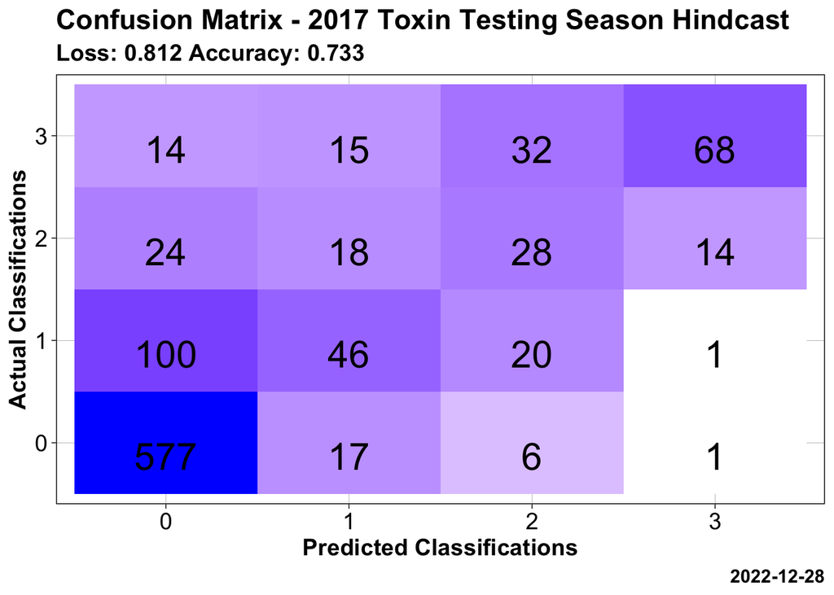

```r
num_levels <- 4
levels <- seq(from=0, to=(num_levels-1))

cm <- as.data.frame(table(predicted = factor(predictions, levels), actual = factor(test$classifications, levels)))

confusion_matrix <- ggplot(data = cm,
                    mapping = aes(x = .data$predicted,
                                  y = .data$actual)) +
  geom_tile(aes(fill = log(.data$Freq+1))) +
  geom_text(aes(label = sprintf("%1.0f", .data$Freq)),
            vjust = 1,
            size=8) +
  scale_fill_gradient(low = "white",
                      high = "blue") +
  labs(x = "Predicted Classifications",
       y = "Actual Classifications",
       title=paste("Confusion Matrix -", YEARS_TESTING, "Toxin Testing Season Hindcast",sep=" "),
       subtitle=paste("Loss:", round(metrics[1], 3), "Accuracy:", round(metrics[2], 3), sep=" "),
       caption=paste(Sys.Date())) +
  theme_linedraw() +
  theme(axis.text=  element_text(size=14),
        axis.title= element_text(size=14,face="bold"),
        title =     element_text(size = 14, face = "bold"),
        legend.position = "none")

confusion_matrix
```